# Ex-01.1-HSB

Paul Johnson

CRMDA  
pauljohn@ku.edu

Feb. 6 2018

Abstract

RHS HSB exercise

# Data import

```r
if (!file.exists("hsb.rds")){
    download.file("http://pj.freefaculty.org/guides/stat/DataSets/HSB/hsb.rds",
                  destfile = "hsb2.rds")
}
    hsb <- readRDS("hsb.rds")
    ## Or do it the hard way
    ## see: http://pj.freefaculty.org/guides/stat/DataSets/HSB/
    ## library(foreign)
    ## hsb.url <- "http://www.stata-press.com/data/mlmus3/hsb.dta"
    ## hsb <- read.dta(hsb.url)
    ## saveRDS(hsb, "hsb.rds")
```

# Descriptive Statistics

## Quick overview

```r
library(rockchalk)
rockchalk::summarize(hsb)
```

```
## Numeric variables
##            minority   female      ses     mathach     size    sector
## min           0          0        -3.76     -2.83    100         0
## med           0          1         0        13.13   1016         0
## max           1          1         2.69     24.99   2713         1
## mean          0.27       0.53      0        12.75   1056.86      0.49
## sd            0.45       0.50      0.78      6.88    604.17      0.50
## skewness      1.01      -0.11     -0.23     -0.18      0.57      0.03
## kurtosis     -0.98      -1.99     -0.38     -0.92     -0.36     -2
## nobs       7185       7185      7185      7185      7185      7185
## nmissing      0          0         0         0         0         0
##            pracad    disclim   himinty   schoolid     mean      sd
## min           0        -2.42      0      1224          4.24      3.54
## med           0.53     -0.23      0      5192         13.16      6.30
## max           1         2.76      1      9586         19.72      8.48
## mean          0.53     -0.13      0.28   5277.90      12.75      6.20
## sd            0.25      0.94      0.45   2499.58       3.01      0.86
## skewness      0.16      0.24      0.98      0.11      -0.27     -0.24
## kurtosis     -0.89     -0.16     -1.04     -1.25      -0.05      0.22
## nobs       7185      7185      7185      7185       7185      7185
## nmissing      0         0         0         0          0         0
##             sdalt      junk    sdalt2      num       se       sealt
## min           6.26      0        48.39     14         0.51      0.76
## med           6.26     30.63     48.39     51         0.89      0.88
## max           6.26    239.29     48.39     67         1.82      1.67
## mean          6.26     47.32     48.39     48.02      0.92      0.92
## sd            0        48.90      0        10.82      0.20      0.13
## skewness       NaN      1.30       NaN     -0.58      1.11      1.59
## kurtosis       NaN      1.46       NaN     -0.37      2.32      3.25
## nobs       7185      7185      7185      7185      7185      7185
## nmissing      0         0         0         0         0         0
##            sealt2      t2       t2alt    pickone    mmses     mnses
## min           0.85      0         0         0        -1.19     -1.19
## med           0.97      5.75      4.36      0         0.03      0.03
## max           1.86    195.81     52.82      1         0.82      0.82
## mean          1.03     14.66      8.54      0.02      0         0
## sd            0.14     26.42     11.06      0.15      0.41      0.41
## skewness      1.59      3.67      2.06      6.47     -0.27     -0.27
## kurtosis      3.25     16.89      4.24     39.92     -0.48     -0.48
## nobs       7185      7185      7185      7185      7185      7185
## nmissing      0         0         0         0         0         0
##              xb       resid
## min           5.68    -19.49
## med          12.87      0.24
## max          17.52     16.44
## mean         12.69      0.06
## sd            2.42      6.46
## skewness     -0.27     -0.14
## kurtosis     -0.48     -0.69
## nobs       7185      7185
## nmissing      0         0
```

## Recodes needed

All of these variables present themselves as numeric variables, but some are clearly categorical. Female is 0 or 1. The R tradition would not have us treat that as a number, but rather it should be a factor variable. Same with minority. Lets make factor versions of them. So we need to make them into factor variables.

I’ll take some liberty here and rename in a way that is, in my opinion, more correct. The variable is “gender” (not female), which takes values Male and Female.

```r
hsb$gender <- factor(hsb$female, levels= c(0, 1), labels = c("Male", "Female"))
hsb$ethnicity <- factor(hsb$minority, levels = c(0, 1), labels = c("White", "Non-white"))
hsb$sector <- factor(hsb$sector, levels = c(0, 1), labels = c("Public", "Catholic"))
```

Double-check the recoding

```r
with(hsb, table(gender, female))
```

```
##         female
## gender      0    1
##   Male   3390    0
##   Female    0 3795
```

```r
with(hsb, table(ethnicity, minority))
```

```
##            minority
## ethnicity      0    1
##   White     5211    0
##   Non-white    0 1974
```

If you are comfortable with those recodes, you can move on. I’m going to remove the original variables, just to show I can.

```r
hsb$female <- NULL
hsb$minority <- NULL
```

If we were going to do any “multi-level” regressions, we would need the school variable as a factor, not as an integer. I’m going to make that one into a factor called schoolidf

```r
hsb$schoolidf <- as.factor(hsb$schoolid)
```

Plainly, there are other variables in the collection that need the same treatment, but I’m not bothering with them now.

```r
rockchalk::summarize(hsb)
```

```
## Numeric variables
##              ses     mathach     size    pracad    disclim   himinty
## min          -3.76     -2.83    100         0        -2.42      0
## med           0        13.13   1016         0.53     -0.23      0
## max           2.69     24.99   2713         1         2.76      1
## mean          0        12.75   1056.86      0.53     -0.13      0.28
## sd            0.78      6.88    604.17      0.25      0.94      0.45
## skewness     -0.23     -0.18      0.57      0.16      0.24      0.98
## kurtosis     -0.38     -0.92     -0.36     -0.89     -0.16     -1.04
## nobs       7185      7185      7185      7185      7185      7185
## nmissing      0         0         0         0         0         0
##            schoolid     mean      sd       sdalt      junk    sdalt2
## min        1224          4.24      3.54      6.26      0        48.39
## med        5192         13.16      6.30      6.26     30.63     48.39
## max        9586         19.72      8.48      6.26    239.29     48.39
## mean       5277.90      12.75      6.20      6.26     47.32     48.39
## sd         2499.58       3.01      0.86      0        48.90      0
## skewness      0.11      -0.27     -0.24       NaN      1.30       NaN
## kurtosis     -1.25      -0.05      0.22       NaN      1.46       NaN
## nobs       7185       7185      7185      7185      7185      7185
## nmissing      0          0         0         0         0         0
##              num       se       sealt    sealt2      t2       t2alt
## min          14         0.51      0.76      0.85      0         0
## med          51         0.89      0.88      0.97      5.75      4.36
## max          67         1.82      1.67      1.86    195.81     52.82
## mean         48.02      0.92      0.92      1.03     14.66      8.54
## sd           10.82      0.20      0.13      0.14     26.42     11.06
## skewness     -0.58      1.11      1.59      1.59      3.67      2.06
## kurtosis     -0.37      2.32      3.25      3.25     16.89      4.24
## nobs       7185      7185      7185      7185      7185      7185
## nmissing      0         0         0         0         0         0
##            pickone    mmses     mnses      xb       resid
## min           0        -1.19     -1.19      5.68    -19.49
## med           0         0.03      0.03     12.87      0.24
## max           1         0.82      0.82     17.52     16.44
## mean          0.02      0         0        12.69      0.06
## sd            0.15      0.41      0.41      2.42      6.46
## skewness      6.47     -0.27     -0.27     -0.27     -0.14
## kurtosis     39.92     -0.48     -0.48     -0.48     -0.69
## nobs       7185      7185      7185      7185      7185
## nmissing      0         0         0         0         0
##
## Nonnumeric variables
##       sector         gender            ethnicity              schoolidf
##  Public  : 3642   Female: 3795     White    : 5211     2305        :   67
##  Catholic: 3543   Male  : 3390     Non-white: 1974     5619        :   66
##  nobs    : 7185   nobs  : 7185     nobs     : 7185     4292        :   65
##  nmiss   :    0   nmiss :    0     nmiss    :    0     3610        :   64
##  entropy      : 1 entropy      : 1 entropy      : 0.85 (All Others): 6923
##  normedEntropy: 1 normedEntropy: 1 normedEntropy: 0.85 nobs        : 7185
##                                                        nmiss       :    0
##                                                        entropy      : 7.27
##                                                        normedEntropy: 0.99
```

```r
str(hsb)
```

```
## 'data.frame':    7185 obs. of  27 variables:
##  $ ses      : num  -1.528 -0.588 -0.528 -0.668 -0.158 ...
##  $ mathach  : num  5.88 19.71 20.35 8.78 17.9 ...
##  $ size     : int  842 842 842 842 842 842 842 842 842 842 ...
##  $ sector   : Factor w/ 2 levels "Public","Catholic": 1 1 1 1 1 1 1 1 1 1 ...
##  $ pracad   : num  0.35 0.35 0.35 0.35 0.35 ...
##  $ disclim  : num  1.6 1.6 1.6 1.6 1.6 ...
##  $ himinty  : int  0 0 0 0 0 0 0 0 0 0 ...
##  $ schoolid : num  1224 1224 1224 1224 1224 ...
##  $ mean     : num  9.72 9.72 9.72 9.72 9.72 ...
##  $ sd       : num  7.59 7.59 7.59 7.59 7.59 ...
##  $ sdalt    : num  6.26 6.26 6.26 6.26 6.26 ...
##  $ junk     : num  45.7 50 59.5 14.9 27.7 ...
##  $ sdalt2   : num  48.4 48.4 48.4 48.4 48.4 ...
##  $ num      : num  47 47 47 47 47 47 47 47 47 47 ...
```

[output cut: 20 more lines]

## Describe Math Achievement with histograms

```r
rockchalk::summarize(hsb$mathach, probs = c(0, .25, .50, .75, 1.0))
```

```
## Numeric variables
##              hsb$mathach
## min            -2.83
## pctile_25%      7.28
## med            13.13
## pctile_75%     18.32
## max            24.99
## mean           12.75
## sd              6.88
## skewness       -0.18
## kurtosis       -0.92
## nobs         7185
## nmissing        0
```

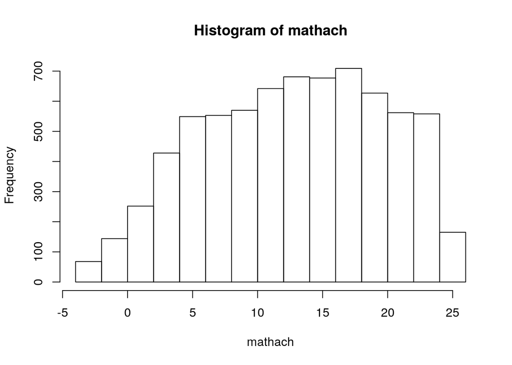

```r
with(hsb, hist(mathach))
```

# 1.1.2 School and variable subsets

I’ll keep some additional variables

```r
keepers <- c("schoolid", "schoolidf", "mathach", "ses", "ethnicity", "gender")
hsb2 <- hsb[hsb$schoolid <= 1317, keepers]
```

```r
summarize(hsb2)
```

```
## Numeric variables
##            schoolid   mathach     ses
## min        1224         -2.83     -1.66
## med        1296         10.61     -0.05
## max        1317         24.99      1.51
## mean       1283.57      11.27     -0.06
## sd           35.85       6.87      0.72
## skewness     -0.90       0.18     -0.12
## kurtosis     -0.87      -1.01     -0.65
## nobs        188        188       188
## nmissing      0          0         0
##
## Nonnumeric variables
##  schoolidf               ethnicity       gender
##  1296 :  48          Non-white:  97   Female: 118
##  1317 :  48          White    :  91   Male  :  70
##  1224 :  47          nobs     : 188   nobs  : 188
##  1288 :  25          nmiss    :   0   nmiss :   0
##  1308 :  20          entropy      : 1 entropy      : 0.95
##  nobs : 188          normedEntropy: 1 normedEntropy: 0.95
##  nmiss:   0
##  entropy      : 2.24
##  normedEntropy: 0.96
```

```r
hsbmeans <- aggregate(hsb2[ , c("mathach", "ses")], by = list(schoolidf = hsb2$schoolidf), mean, na.rm = TRUE)
hsbsds <- aggregate(hsb2[ , c("mathach", "ses")], by = list(schoolidf = hsb2$schoolidf), sd, na.rm = TRUE)
merge(hsbmeans, hsbsds, by = "schoolidf", suffixes = c("mean", "sd"))
```

```
##   schoolidf mathachmean    sesmean mathachsd     sessd
## 1      1224    9.715447 -0.4343830  7.592785 0.6272834
## 2      1288   13.510800  0.1216000  7.021843 0.6692812
## 3      1296    7.635958 -0.4255000  5.351070 0.6470276
## 4      1308   16.255500  0.5280000  6.114241 0.4798070
## 5      1317   13.177688  0.3453333  5.462586 0.5561583
```

# Plots

## 1.1.3 histogram

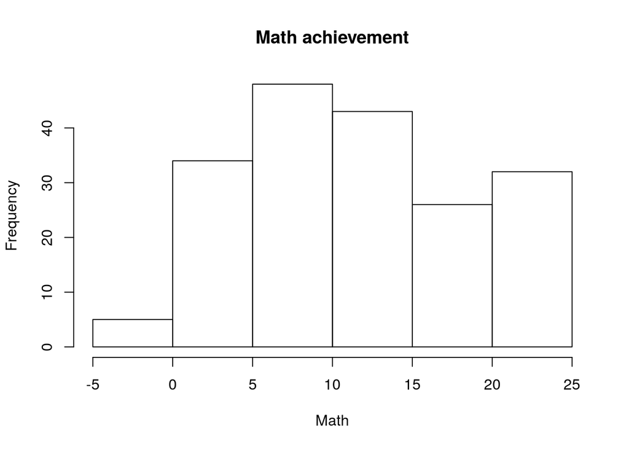

```r
hist(hsb2$mathach, main = "Math achievement", xlab = "Math")
```

## boxplot

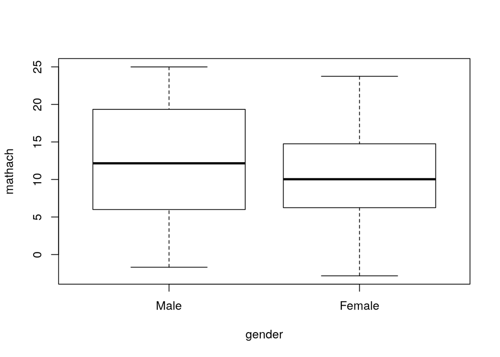

```r
plot(mathach ~ gender, data = hsb2)
```

Note: plot was a shortcut

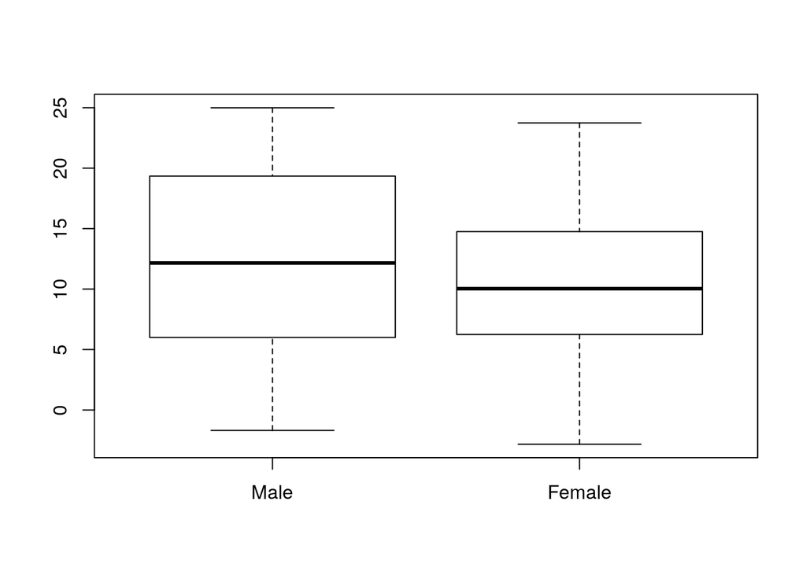

```r
boxplot(mathach ~ gender, data = hsb2)
```

Beautify with labels:

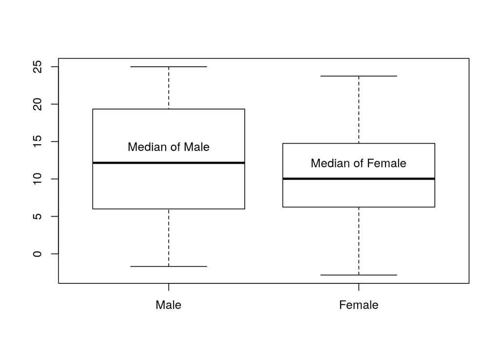

```r
bp1 <- boxplot(mathach ~ gender, data = hsb2)

text(1, 14.3, "Median of Male")
text(2, 12.1, "Median of Female")
```

## 1.1.4 Show a scatterplot of 2 “numeric” variables

I’ll adjust range to look like the stata output

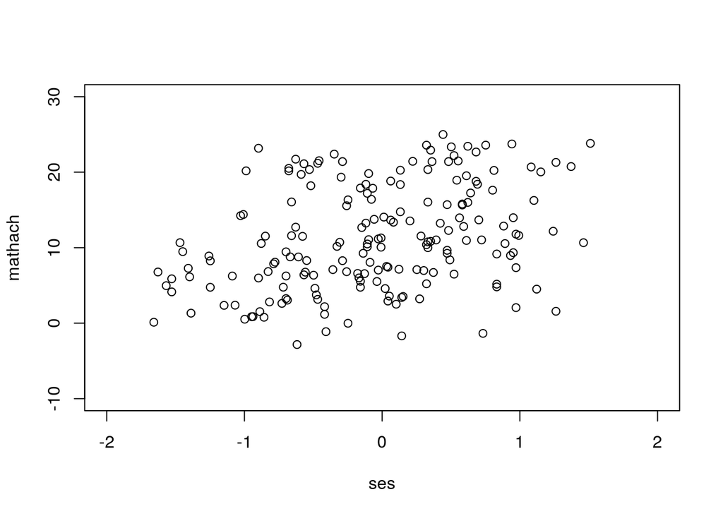

```r
plot(mathach ~ ses, data = hsb2, xlim = c(-2, 2),
     ylim = c(-10, 30))
```

## Trellis plot with R lattice

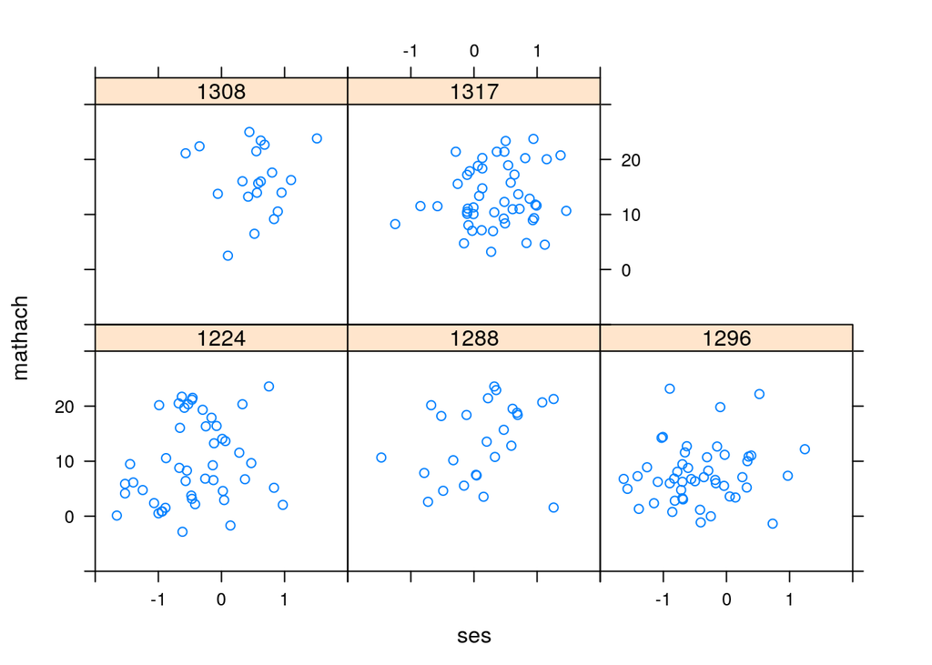

```r
library(lattice)
xyplot(mathach ~ ses | schoolidf, data = hsb2,
        xlim = c(-2, 2),
     ylim = c(-10, 30))
```

The ggplot2 variant of same

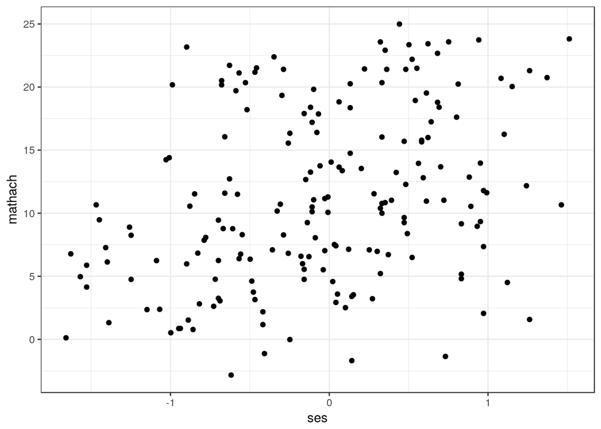

```r
library(ggplot2)
theme_set(theme_bw())
ggplot(data = hsb2, aes(x=ses, y=mathach)) +
  geom_point()
```

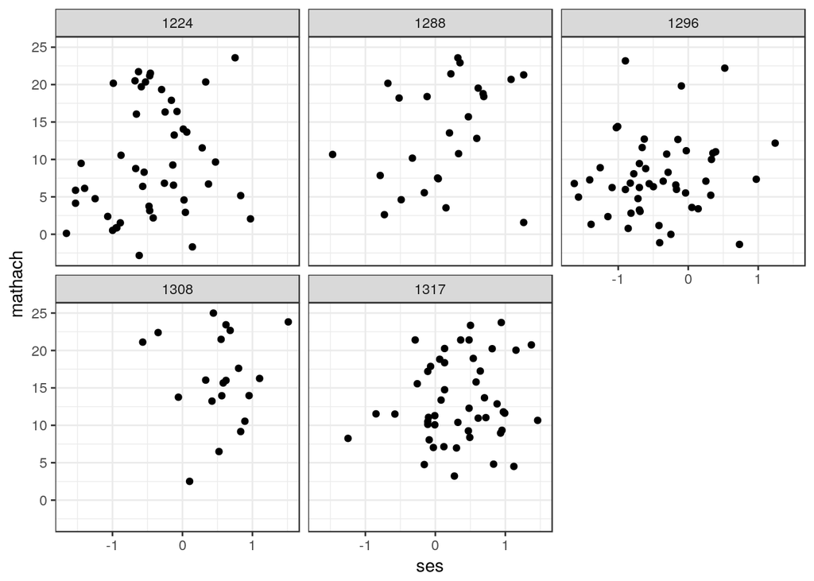

```r
library(ggplot2)
theme_set(theme_bw())
ggplot(data = hsb2, aes(x=ses, y=mathach)) +
  geom_point() +
  facet_wrap(~ schoolid)
```

## Make list of subsets with split and plot them.

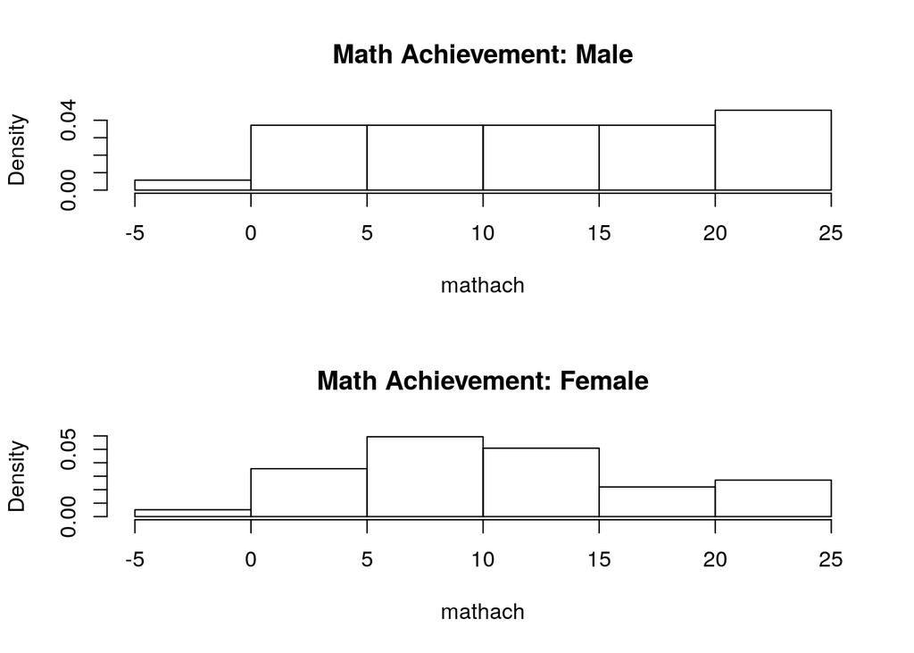

```
## $Male
## $breaks
## [1] -5  0  5 10 15 20 25
##
## $counts
## [1]  2 13 13 13 13 16
##
## $density
## [1] 0.005714286 0.037142857 0.037142857 0.037142857 0.037142857 0.045714286
##
## $mids
## [1] -2.5  2.5  7.5 12.5 17.5 22.5
##
## $xname
## [1] "mathach"
##
## $equidist
## [1] TRUE
##
## attr(,"class")
## [1] "histogram"
##
## $Female
## $breaks
## [1] -5  0  5 10 15 20 25
##
## $counts
## [1]  3 21 35 30 13 16
##
## $density
## [1] 0.005084746 0.035593220 0.059322034 0.050847458 0.022033898 0.027118644
##
## $mids
## [1] -2.5  2.5  7.5 12.5 17.5 22.5
##
## $xname
## [1] "mathach"
##
## $equidist
## [1] TRUE
##
## attr(,"class")
## [1] "histogram"
```

```r
hsbsplit <- split(hsb2, hsb2$gender)

par(mfrow = c(2,1))
lapply(hsbsplit, function(subdat){
    with(subdat, hist(mathach, prob = TRUE,
                      main = paste("Math Achievement:",
                                   unique(subdat$gender))))})
```

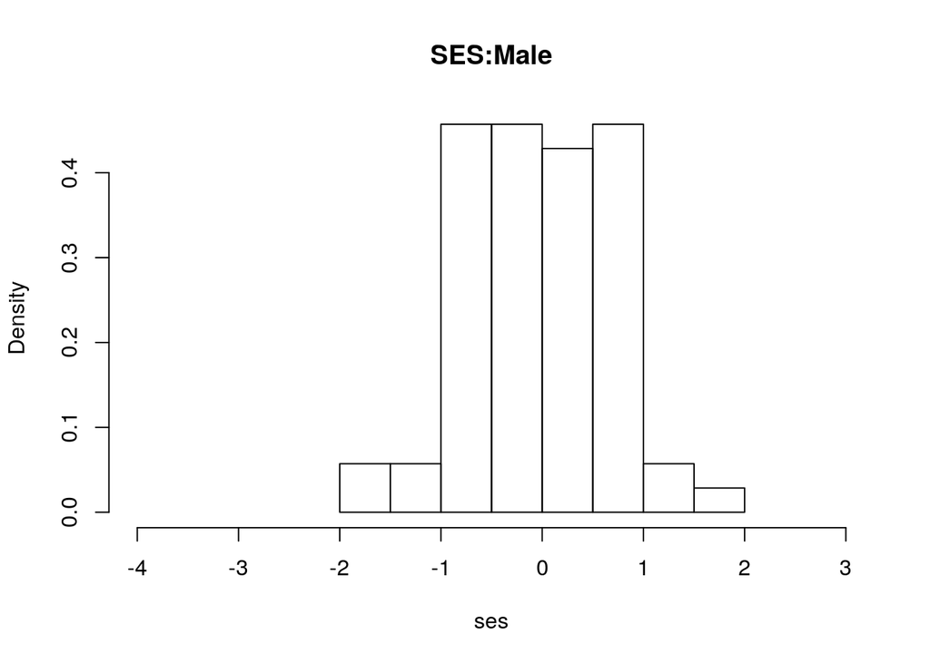

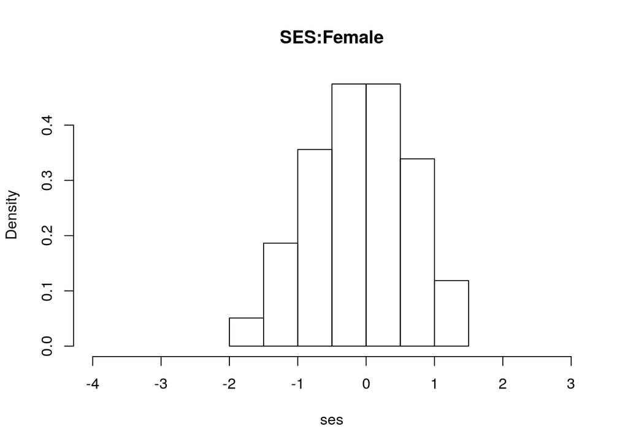

```
## $Male
## $breaks
## [1] -2.0 -1.5 -1.0 -0.5  0.0  0.5  1.0  1.5  2.0
##
## $counts
## [1]  2  2 16 16 15 16  2  1
##
## $density
## [1] 0.05714286 0.05714286 0.45714286 0.45714286 0.42857143 0.45714286
## [7] 0.05714286 0.02857143
##
## $mids
## [1] -1.75 -1.25 -0.75 -0.25  0.25  0.75  1.25  1.75
##
## $xname
## [1] "ses"
##
## $equidist
## [1] TRUE
##
## attr(,"class")
## [1] "histogram"
##
## $Female
## $breaks
## [1] -2.0 -1.5 -1.0 -0.5  0.0  0.5  1.0  1.5
##
## $counts
## [1]  3 11 21 28 28 20  7
##
## $density
## [1] 0.05084746 0.18644068 0.35593220 0.47457627 0.47457627 0.33898305
## [7] 0.11864407
##
## $mids
## [1] -1.75 -1.25 -0.75 -0.25  0.25  0.75  1.25
##
## $xname
## [1] "ses"
##
## $equidist
## [1] TRUE
##
## attr(,"class")
## [1] "histogram"
```

```r
lapply(hsbsplit, function(subdat) {
    with(subdat, hist(ses, prob = TRUE, xlim = c(-4, 3),
                      main = paste0("SES:", unique(subdat$gender))))})
```

## 1.1.5 Regression

```r
m0 <- lm(mathach ~ ses, data = hsb2)
```

```r
m0.or <- outreg(list("Linear Model" = m0), type = "html", browse = FALSE)
```

```r
m0.or <- gsub("[ ]{2,}", " ", m0.or)
cat(m0.or)
```

Linear Model

Estimate

(S.E.)

(Intercept)

11.457***

(0.473)

ses

3.307***

(0.660)

N

188

RMSE

6.471

R<sup>2</sup>

0.119

- p ≤0.05** p ≤0.01*** p ≤0.001

```r
confint(m0)
```

```
##                 2.5 %    97.5 %
## (Intercept) 10.522568 12.390480
## ses          2.004499  4.609427
```

## 1.1.6 Predict

```r
hsb2$yhat <- predict(m0)
head(hsb2)
```

```
##   schoolid schoolidf mathach    ses ethnicity gender      yhat
## 1     1224      1224   5.876 -1.528     White Female  6.403484
## 2     1224      1224  19.708 -0.588     White Female  9.512029
## 3     1224      1224  20.349 -0.528     White   Male  9.710447
## 4     1224      1224   8.781 -0.668     White   Male  9.247472
## 5     1224      1224  17.898 -0.158     White   Male 10.934024
## 6     1224      1224   4.583  0.022     White   Male 11.529277
```

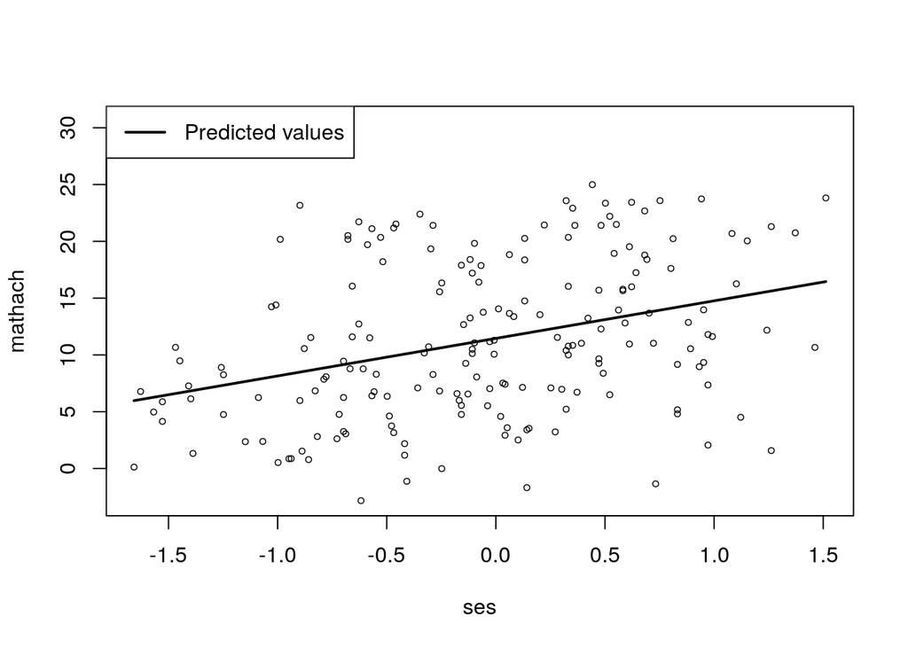

```r
plotSlopes(m0, plotx = "ses")
```

```r
m0.pom <- predictOMatic(m0, interval="confidence")
m0.pom$ses$mathach <- m0.pom$ses$fit
m0.pom
```

```
## $ses
##       ses       fit       lwr       upr   mathach
## 1 -1.6580  5.973579  3.689599  8.257559  5.973579
## 2 -0.5930  9.495495  8.331583 10.659407  9.495495
## 3 -0.0480 11.297789 10.366691 12.228888 11.297789
## 4  0.4845 13.058747 11.890957 14.226537 13.058747
## 5  1.5120 16.456652 14.211322 18.701982 16.456652
```

Maybe you like a confidence interval as well

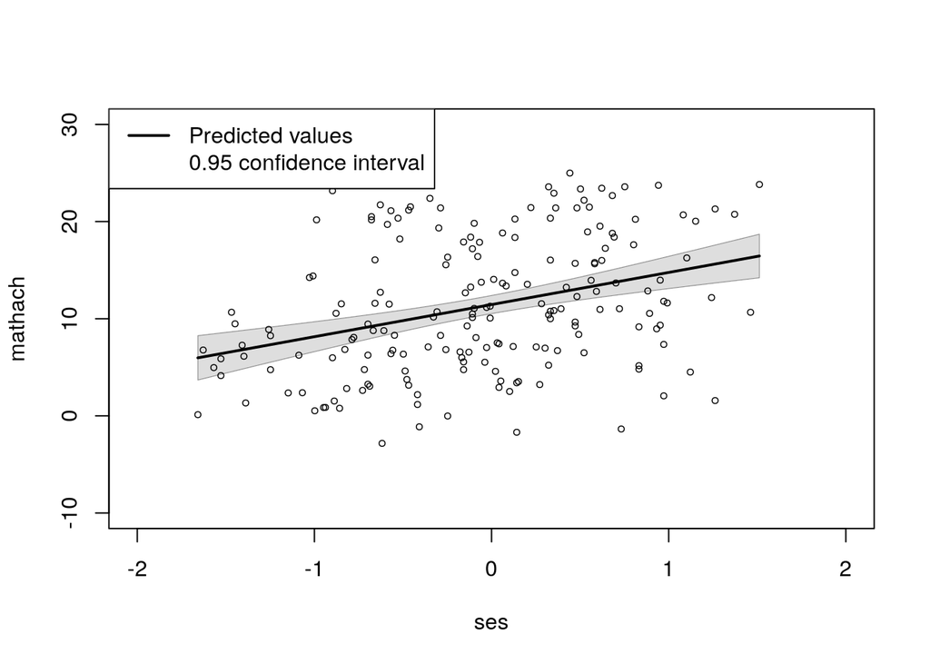

```r
plotSlopes(m0, plotx = "ses", interval = "confidence", xlim = c(-2, 2),
           ylim = c(-10, 30))
```

What best way to get plot for each school.

My plotSlopes approach is not what they want

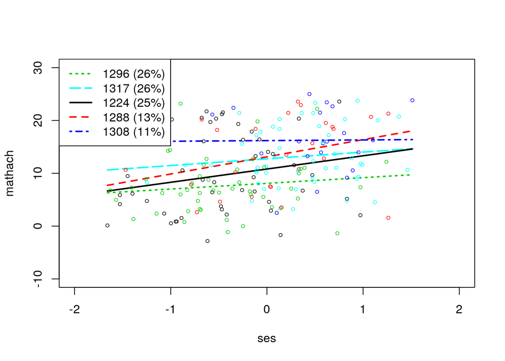

```r
m1 <- lm(mathach ~ ses * schoolidf, data = hsb2)
plotSlopes(m1, plotx = "ses", modx = "schoolidf", xlim = c(-2, 2),
           ylim = c(-10, 30))
```

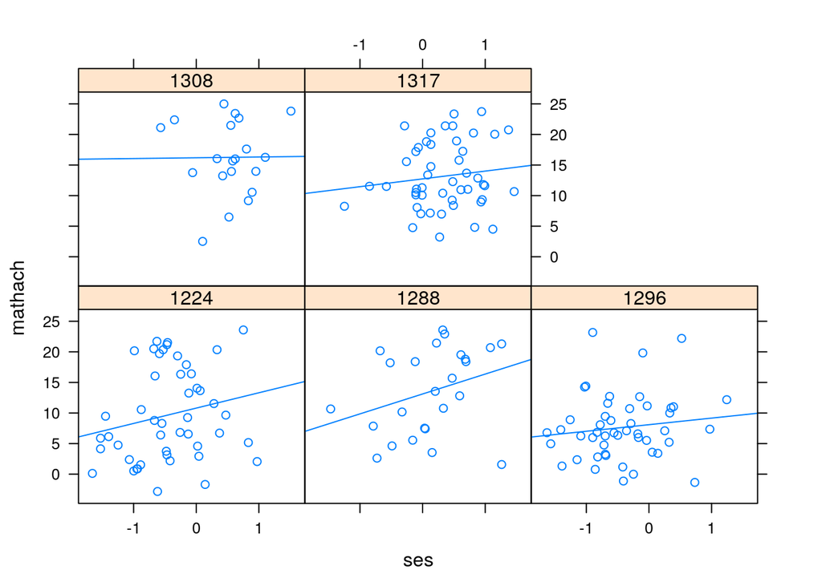

```r
xyplot(mathach ~ ses | schoolidf, data = hsb2, type = c("p", "r"))
```

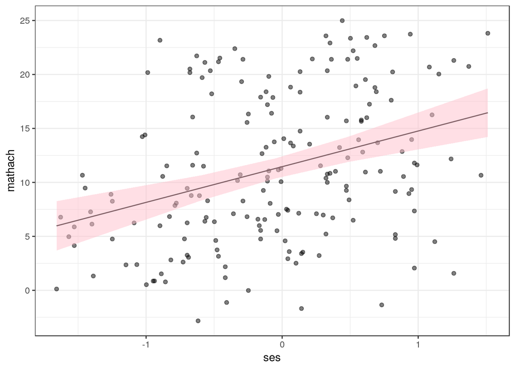

```r
library(ggplot2)
theme_set(theme_bw())
ggplot(data = hsb2, aes(x=ses, y=mathach)) + geom_point(alpha=0.5) +
    geom_line(data = m0.pom$ses) +
    geom_ribbon(data = m0.pom$ses, aes(ymin = lwr, ymax = upr), fill = "pink", alpha = 0.5)
```

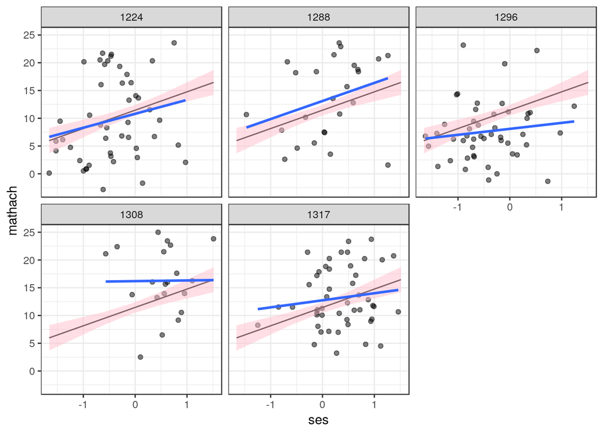

```r
ggplot(data = hsb2, aes(x=ses, y=mathach)) + geom_point(alpha=0.5) +
    geom_line(data = m0.pom$ses) +
    geom_ribbon(data = m0.pom$ses, aes(ymin = lwr, ymax = upr), fill = "pink", alpha = 0.5) +
    geom_smooth(method="lm", fill = NA) +
    facet_wrap(~ schoolidf)
```

## 1.1.8 Regression with school as a factor

I already ran this one in previous, but I used interaction, not an additive model. So here it is, additive!

```r
m2 <- lm(mathach ~ ses + schoolidf, data = hsb2)
summary(m2)
```

```
##
## Call:
## lm(formula = mathach ~ ses + schoolidf, data = hsb2)
##
## Residuals:
##      Min       1Q   Median       3Q      Max
## -13.9759  -4.1968  -0.7519   5.2209  16.3813
##
## Coefficients:
##               Estimate Std. Error t value Pr(>|t|)
## (Intercept)    10.4925     0.9676  10.844  < 2e-16 ***
## ses             1.7890     0.7594   2.356  0.01955 *
## schoolidf1288   2.8007     1.6004   1.750  0.08180 .
## schoolidf1296  -2.0954     1.2797  -1.637  0.10328
## schoolidf1308   4.8184     1.8183   2.650  0.00876 **
## schoolidf1317   2.0674     1.4101   1.466  0.14433
## ---
## Signif. codes:  0 '***' 0.001 '**' 0.01 '*' 0.05 '.' 0.1 ' ' 1
##
## Residual standard error: 6.236 on 182 degrees of freedom
## Multiple R-squared:  0.1992, Adjusted R-squared:  0.1772
## F-statistic: 9.054 on 5 and 182 DF,  p-value: 1.051e-07
```

## Test the school coefficients, jointly

```r
anova(m0, m2)
```

```
## Analysis of Variance Table
##
## Model 1: mathach ~ ses
## Model 2: mathach ~ ses + schoolidf
##   Res.Df    RSS Df Sum of Sq      F   Pr(>F)
## 1    186 7788.1
## 2    182 7078.0  4    710.09 4.5647 0.001549 **
## ---
## Signif. codes:  0 '***' 0.001 '**' 0.01 '*' 0.05 '.' 0.1 ' ' 1
```

## 1.1.9 Lets see if there is an interaction between ses and school

```r
m3 <- lm(mathach ~ ses * schoolidf, data = hsb2)
summary(m3)
```

```
##
## Call:
## lm(formula = mathach ~ ses * schoolidf, data = hsb2)
##
## Residuals:
##      Min       1Q   Median       3Q      Max
## -15.6483  -4.4246  -0.8679   4.6355  16.0444
##
## Coefficients:
##                   Estimate Std. Error t value Pr(>|t|)
## (Intercept)        10.8051     1.1181   9.664   <2e-16 ***
## ses                 2.5086     1.4761   1.700   0.0910 .
## schoolidf1288       2.3098     1.6976   1.361   0.1753
## schoolidf1296      -2.7114     1.5603  -1.738   0.0840 .
## schoolidf1308       5.3838     2.3949   2.248   0.0258 *
## schoolidf1317       1.9326     1.5477   1.249   0.2134
## ses:schoolidf1288   0.7469     2.4181   0.309   0.7578
## ses:schoolidf1296  -1.4326     2.0452  -0.700   0.4845
## ses:schoolidf1308  -2.3826     3.3458  -0.712   0.4773
## ses:schoolidf1317  -1.2347     2.2116  -0.558   0.5774
## ---
## Signif. codes:  0 '***' 0.001 '**' 0.01 '*' 0.05 '.' 0.1 ' ' 1
##
## Residual standard error: 6.28 on 178 degrees of freedom
## Multiple R-squared:  0.2058, Adjusted R-squared:  0.1657
## F-statistic: 5.125 on 9 and 178 DF,  p-value: 3.569e-06
```

## Lets see if there is an interaction between ses and gender

```r
m1 <- lm(mathach ~ ses * gender, data = hsb2)
summary(m1)
```

```
##
## Call:
## lm(formula = mathach ~ ses * gender, data = hsb2)
##
## Residuals:
##      Min       1Q   Median       3Q      Max
## -16.4908  -5.0651  -0.6561   5.5142  14.0622
##
## Coefficients:
##                  Estimate Std. Error t value Pr(>|t|)
## (Intercept)       12.4308     0.7731  16.079  < 2e-16 ***
## ses                3.6982     1.1439   3.233  0.00145 **
## genderFemale      -1.5598     0.9769  -1.597  0.11207
## ses:genderFemale  -0.6208     1.3997  -0.444  0.65791
## ---
## Signif. codes:  0 '***' 0.001 '**' 0.01 '*' 0.05 '.' 0.1 ' ' 1
##
## Residual standard error: 6.459 on 184 degrees of freedom
## Multiple R-squared:  0.1314, Adjusted R-squared:  0.1173
## F-statistic: 9.281 on 3 and 184 DF,  p-value: 9.556e-06
```

```r
m2 <-  lm(mathach ~ ses + gender, data = hsb2)
summary(m2)
```

```
##
## Call:
## lm(formula = mathach ~ ses + gender, data = hsb2)
##
## Residuals:
##      Min       1Q   Median       3Q      Max
## -16.1725  -4.9985  -0.6291   5.3611  13.7046
##
## Coefficients:
##              Estimate Std. Error t value Pr(>|t|)
## (Intercept)   12.4160     0.7707  16.110  < 2e-16 ***
## ses            3.2835     0.6578   4.992 1.38e-06 ***
## genderFemale  -1.5307     0.9726  -1.574    0.117
## ---
## Signif. codes:  0 '***' 0.001 '**' 0.01 '*' 0.05 '.' 0.1 ' ' 1
##
## Residual standard error: 6.445 on 185 degrees of freedom
## Multiple R-squared:  0.1305, Adjusted R-squared:  0.1211
## F-statistic: 13.88 on 2 and 185 DF,  p-value: 2.413e-06
```

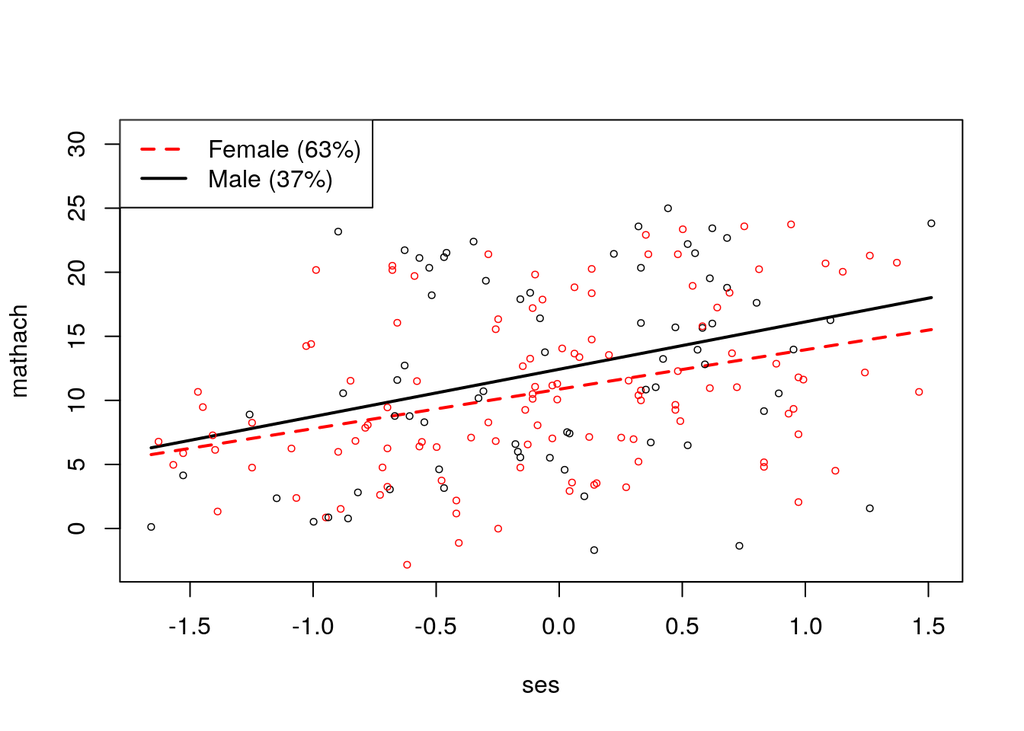

```r
library(rockchalk)
plotSlopes(m1, plotx = "ses", modx = "gender")
```

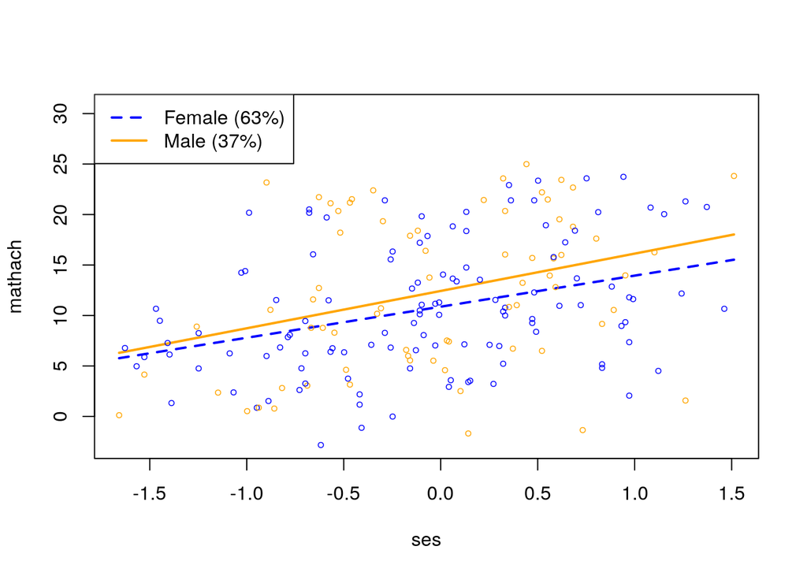

```r
plotSlopes(m1, plotx = "ses", modx = "gender", col = c("orange", "blue"))
```

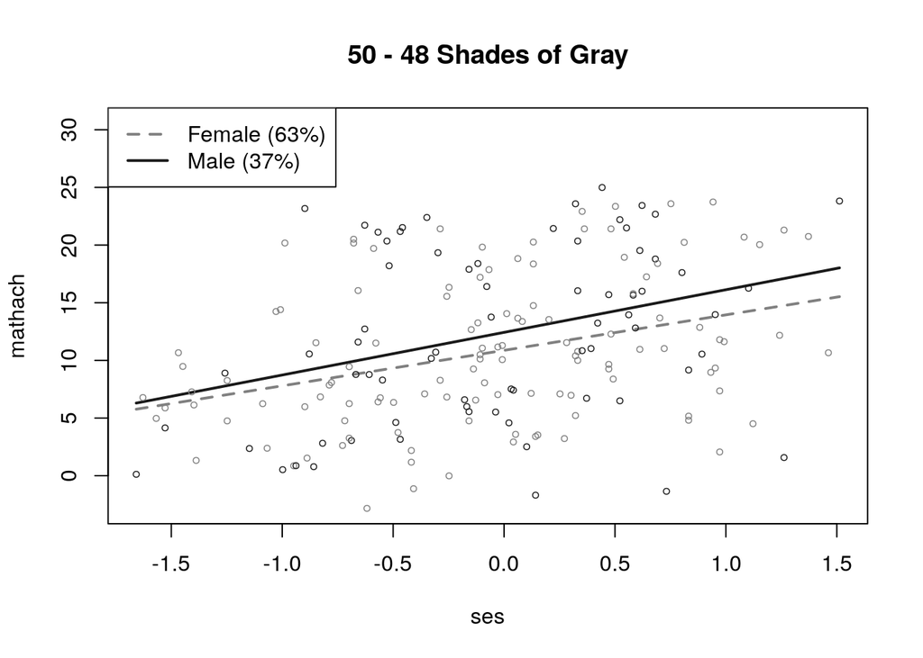

```r
plotSlopes(m1, plotx = "ses", modx = "gender",
           col = gray.colors(2, 0.1, 0.5),
           main = "50 - 48 Shades of Gray")
```

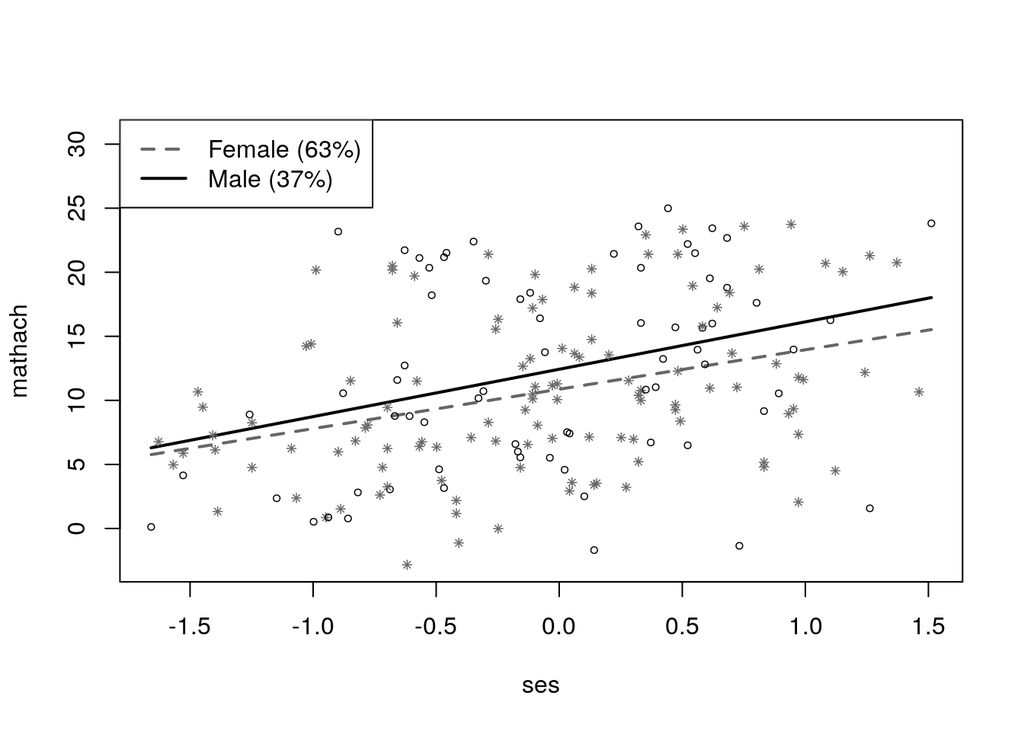

```r
mycol <- c("black", "gray40")
mypch <- c(1, 8)
plotSlopes(m1, plotx = "ses", modx = "gender", col = mycol, pch = mypch[hsb2$gender])
```

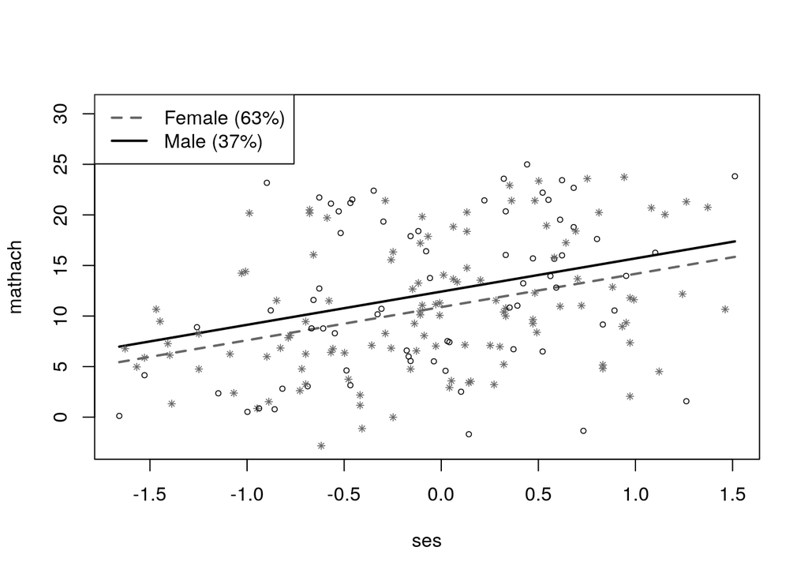

```r
plotSlopes(m2, plotx = "ses", modx = "gender", col = mycol, pch = mypch[hsb2$gender] )
```

## Compare the p-value from the anova test

```r
anova(m1, m2)
```

```
## Analysis of Variance Table
##
## Model 1: mathach ~ ses * gender
## Model 2: mathach ~ ses + gender
##   Res.Df    RSS Df Sum of Sq      F Pr(>F)
## 1    184 7677.0
## 2    185 7685.2 -1   -8.2076 0.1967 0.6579
```